# Análisis lingüístico de los errores de ICR: motor OlmOCR

Tipos de error, preservación de entidades y estabilidad entre documentos

Autores/as

Afiliación

Alejandro Bernal

Universidad Externado de Colombia

Angie Donato

Universidad Externado de Colombia

**Resumen.** Este reporte caracteriza los errores de un motor de reconocimiento inteligente de caracteres (ICR), OlmOCR, sobre 30 documentos administrativos colombianos manuscritos, a partir de su comparación con una transcripción manual. En lugar de resumir el desempeño en la tasa de error de caracteres (CER, mediana de 9,2 %) y de palabras (WER, 21,7 %), se analizan tres dimensiones: los tipos de error de carácter, entre los que predominan las sustituciones (54,3 % de las operaciones de edición); la preservación de entidades administrativas, que va de 26,5 % a 69,5 % según la categoría; y la estabilidad entre documentos, con un CER máximo de 18,1 % (2,0 veces la mediana). Un contraste descriptivo con el desempeño del mismo motor en folios impresos muestra un error típico mucho mayor en los manuscritos y un cambio en el perfil de error, de omisiones a sustituciones. El análisis es reproducible con R y Quarto a partir de un archivo de configuración.

**Palabras clave:** ICR, OlmOCR, tasa de error de caracteres, preservación de entidades, estabilidad, documentos administrativos, español.

# 1 Introducción

La comparación cuantitativa habitual entre motores ICR resume el desempeño en la tasa de error de caracteres (CER), la tasa de error de palabras (WER) y el tiempo por página. Estas métricas son útiles para escoger un motor, pero promedian todos los errores por igual: dos motores con un CER similar pueden equivocarse de maneras muy distintas y conservar información muy distinta. Para tareas administrativas concretas, como recuperar nombres en un padrón, ubicar fechas en una resolución o localizar identificadores en un formulario, el promedio es insuficiente.

Este reporte propone un análisis complementario sobre documentos administrativos colombianos. En lugar de reducir el motor a unos pocos números, caracteriza su comportamiento erróneo desde tres dimensiones: los tipos de error a nivel de carácter, la preservación de entidades administrativas y la estabilidad del error entre documentos. La pregunta cambia de qué motor tiene menor error promedio a qué información preserva el motor y con cuánta regularidad. Aquí se analiza 1 motor (**OlmOCR**) sobre 30 documentos; CER y WER se incluyen solo como contexto. El diseño admite varios motores: se agregan en `config.yml`.

# 2 Datos y métodos

## 2.1 Corpus y motores

El corpus consta de 30 documentos administrativos colombianos. Para cada documento se dispone de la transcripción manual de referencia y de la salida de OlmOCR. El motor se ejecutó previamente: este reporte no ejecuta ICR, recibe las salidas en texto plano alineadas con la referencia, documento por documento, y se concentra en el análisis posterior, implementado en R.

Cada línea de los archivos de entrada es un documento (Figura 1), de modo que 30 documentos × 1 motor = 30 observaciones.

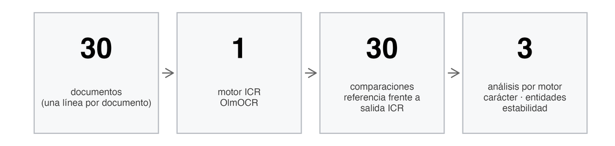

Figura 1. Flujo del análisis lingüístico. Los 30 documentos se procesan con 1 motor ICR, lo que produce 30 comparaciones entre la transcripción de referencia y la salida ICR; cada comparación alimenta los tres análisis: errores de carácter, preservación de entidades y estabilidad entre documentos.

## 2.2 Normalización y métricas auxiliares

El CER es la distancia de Levenshtein a nivel de carácter entre la referencia y la salida del motor, dividida por la longitud de la referencia:

$$\mathrm{CER} = \frac{S + D + I}{N}
\qquad(1)$$

donde $S$, $D$ e $I$ son las sustituciones, omisiones e inserciones necesarias para transformar la referencia en la salida, y $N$ es el número de caracteres de la referencia (Ecuación 1). El WER se define igual a nivel de palabra, donde una palabra es una secuencia de letras o dígitos, sin puntuación. La normalización es mínima: se quitan las comillas que envuelven cada línea del CSV y se deshace la duplicación de las comillas internas. No se corrige la ortografía, no se eliminan las tildes, se distingue entre mayúsculas y minúsculas en el cálculo del CER y la puntuación se conserva.

Para clasificar los errores de carácter se recuperan las operaciones de edición (sustitución, omisión e inserción) con `adist()`. La distancia total obtenida a partir de esas operaciones se validó contra `stringdist`: sobre las 30 salidas disponibles hubo 0 discrepancias.

## 2.3 Análisis lingüístico en R

El análisis se organiza en tres componentes:

1. **Errores de carácter.** Composición del error en sustituciones, omisiones e inserciones, y matriz de confusiones entre el carácter de referencia y el carácter ICR. Para su lectura, cada sustitución se agrupa según los caracteres implicados: confusión entre letras, tildes y diacríticos, letra por dígito, comillas y apóstrofos, puntuación u otras; esta agrupación no altera los conteos.
2. **Preservación de entidades administrativas.** Fechas, números, nombres propios y códigos administrativos se extraen de la referencia con expresiones regulares y un diccionario léxico revisado manualmente (con `quanteda`), y se buscan en la salida del mismo documento. La comparación no distingue mayúsculas, no elimina tildes, no corrige el texto ICR y no equipara caracteres visualmente parecidos; solo se ignora el punto ordinal de las fechas («23.» frente a «23»). La tasa de preservación es la proporción de entidades de la referencia presentes en la salida.
3. **Estabilidad entre documentos.** Distribución del CER y del WER entre los documentos de cada motor, resumida con la mediana, el rango intercuartílico (IQR), el percentil 90 (P90) y el máximo, sin excluir valores extremos ni truncar las tasas en 1.

`stringdist` aporta el alineamiento subyacente de la distancia de Levenshtein, `tidytext` aporta la integración tabular a nivel de token (apéndice E), `tidyverse` organiza las estructuras de datos, `ggplot2` produce las visualizaciones y Quarto compila el reporte.

# 3 Resultados

## 3.1 CER y WER como contexto cuantitativo

Estas métricas permiten situar el desempeño global del motor (Figura 2), pero no explican la naturaleza del error.

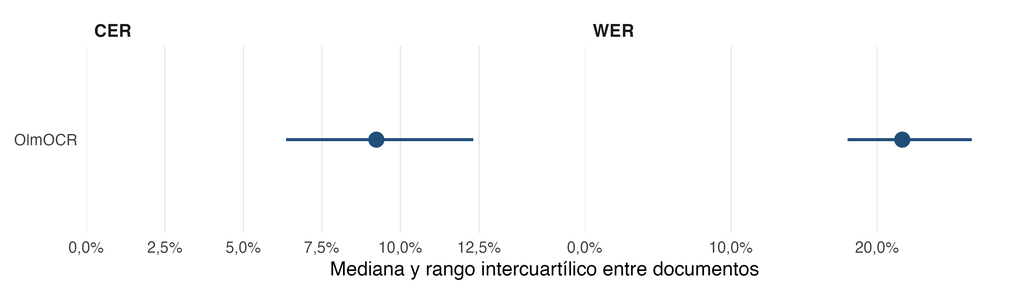

Figura 2. CER y WER por motor. El punto marca la mediana entre los 30 documentos y la línea, el rango intercuartílico (percentiles 25 a 75). Un valor menor indica menor error. Cada panel tiene su propia escala horizontal.

La mediana del CER de OlmOCR es 9,2 % y la del WER, 21,7 %; el WER mediano supera al CER mediano, como es esperable: un solo carácter erróneo invalida la palabra completa. Sumando todos los documentos, el CER global es 9,88 %. Los siguientes tres análisis constituyen el núcleo del estudio.

## 3.2 Errores a nivel de carácter

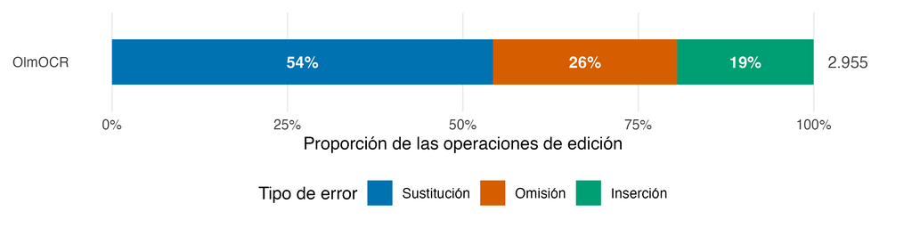

Figura 3. Composición de los errores de carácter por motor. Cada barra suma el 100 % de las operaciones de edición y se reparte entre sustituciones, omisiones e inserciones; el número a la derecha es el total de operaciones. La figura compara la composición, no el volumen de errores.

En OlmOCR predominan las sustituciones (Figura 3): son el 54,3 % de sus operaciones de edición (54,3 % sustituciones, 26,2 % omisiones y 19,5 % inserciones). El total es de 2.955 operaciones sobre 29.903 caracteres de referencia, como muestra la Tabla 1.

Tabla 1. Operaciones de edición por motor y tipo de error.

| Motor | Sustituciones | Omisiones | Inserciones | Total |
| --- | --- | --- | --- | --- |
| OlmOCR | 1.605 | 775 | 575 | 2.955 |

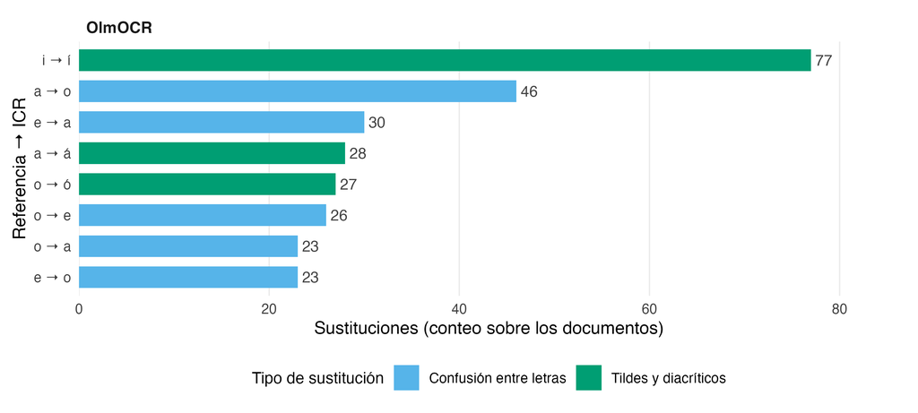

Figura 4. Principales sustituciones de carácter por motor. Cada panel muestra las ocho sustituciones más frecuentes; la barra indica cuántas veces el carácter de la referencia fue reemplazado por el carácter ICR indicado y el color, el tipo de sustitución.

Como muestra la Figura 4, la sustitución más frecuente de OlmOCR es i → í (77). Tres patrones lingüísticos se distinguen. Primero, las sustituciones que confunden una letra con un dígito (por ejemplo, l por 1 u o por 0) representan el 0,4 % de las sustituciones; este tipo de confusión compromete números y códigos. Segundo, las sustituciones asociadas a tildes y diacríticos representan el 12,6 %: el motor añade una tilde que la referencia no tiene en 154 casos, la pierde en 49 y la cambia por otra en 0. Tercero, las que solo cambian el tipo de comilla o apóstrofo representan el 0,1 %; son variantes tipográficas que no alteran la palabra transcrita.

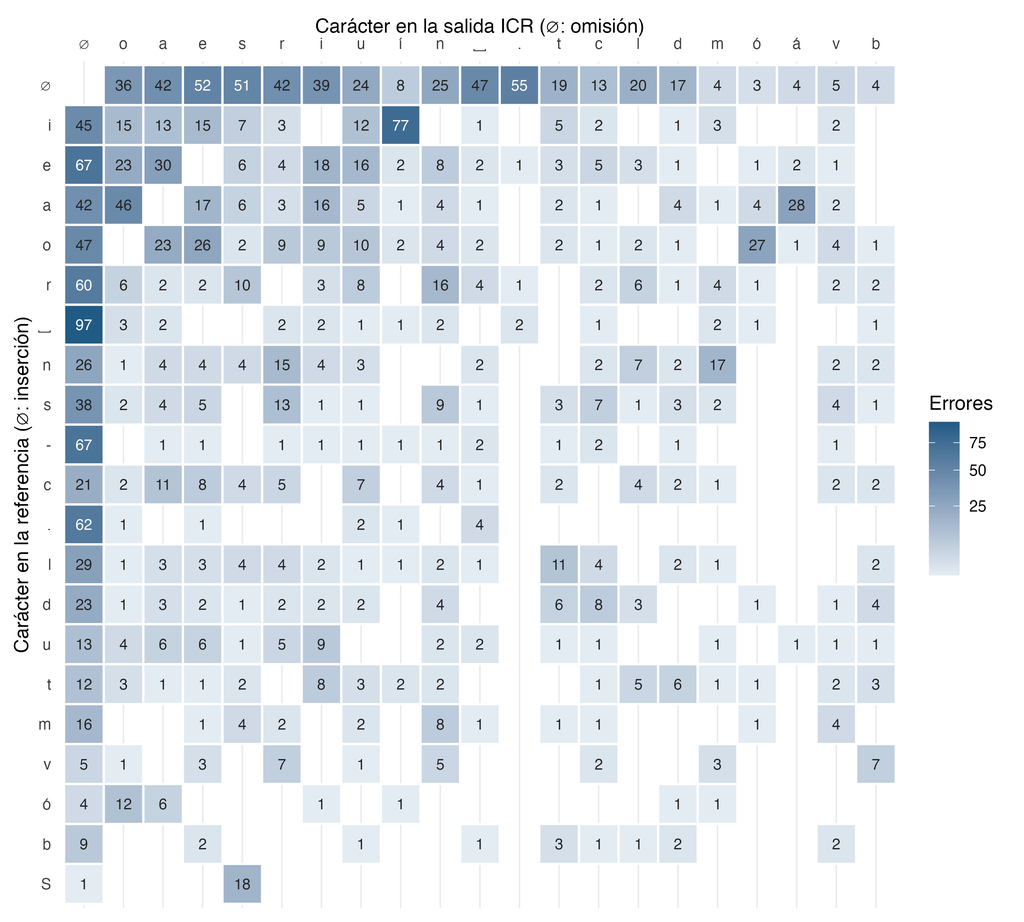

Figura 5. Matriz de confusión de caracteres de OlmOCR. Cada celda cuenta cuántas veces el carácter de la referencia (fila) apareció como el carácter de la salida ICR (columna); ∅ marca las omisiones (columna) y las inserciones (fila). Se muestran los 20 caracteres con más errores de cada lado; el color usa una escala de raíz cuadrada para que los pares poco frecuentes no se pierdan.

La matriz de confusión (Figura 5) incluye lo que la lista de sustituciones no muestra. Lo más omitido es «espacio» (97 veces) y lo más insertado, «.» (55); la Tabla 2 resume los cinco casos más frecuentes de cada tipo.

Tabla 2. Caracteres más omitidos e insertados.

| Puesto | Carácter omitido | Veces | Carácter insertado | Veces |
| --- | --- | --- | --- | --- |
| 1 | espacio | 97 | . | 55 |
| 2 | e | 67 | e | 52 |
| 3 | guion | 67 | s | 51 |
| 4 | . | 62 | espacio | 47 |
| 5 | r | 60 | a | 42 |

## 3.3 Preservación de entidades administrativas

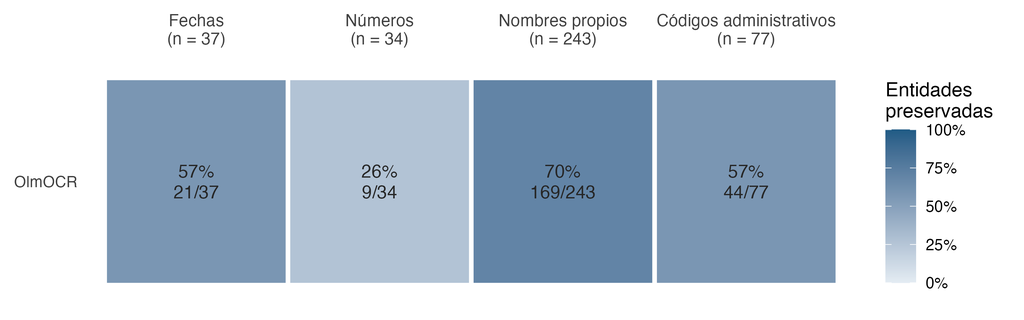

Figura 6. Preservación de entidades administrativas por motor y categoría. El color y el porcentaje indican la proporción de entidades de la referencia presentes en la salida del motor; debajo se muestra el número de entidades preservadas sobre el número evaluado en la categoría. Un valor mayor indica mejor preservación.

La Figura 6 resume la preservación por categoría:

- **Fechas** (n = 37): 56,8 %.
- **Números** (n = 34): 26,5 %.
- **Nombres propios** (n = 243): 69,5 %.
- **Códigos administrativos** (n = 77): 57,1 %.

La categoría con menos entidades (números, n = 34) es sensible a un solo acierto o error: una entidad equivale a 2,9 pp. Entre los números, 22 de 34 son ordinales (como 2ª) y solo 1 se preserva, porque la salida los escribe con otro signo (2°); sin los ordinales, la tasa de números sería 66,7 %.

## 3.4 Estabilidad entre documentos

¿Es el desempeño del motor consistente entre documentos? La Tabla 3 y la Figura 7 resumen la distribución del error.

Tabla 3. Distribución del CER y del WER entre documentos (IQR: rango intercuartílico; P90: percentil 90; máx.: valor máximo).

| Motor | CER mediana | CER IQR | CER P90 | CER máx. | WER mediana | WER IQR | WER P90 | WER máx. |
| --- | --- | --- | --- | --- | --- | --- | --- | --- |
| OlmOCR | 9,2 % | 6,0 % | 15,2 % | 18,1 % | 21,7 % | 8,5 % | 29,7 % | 41,6 % |

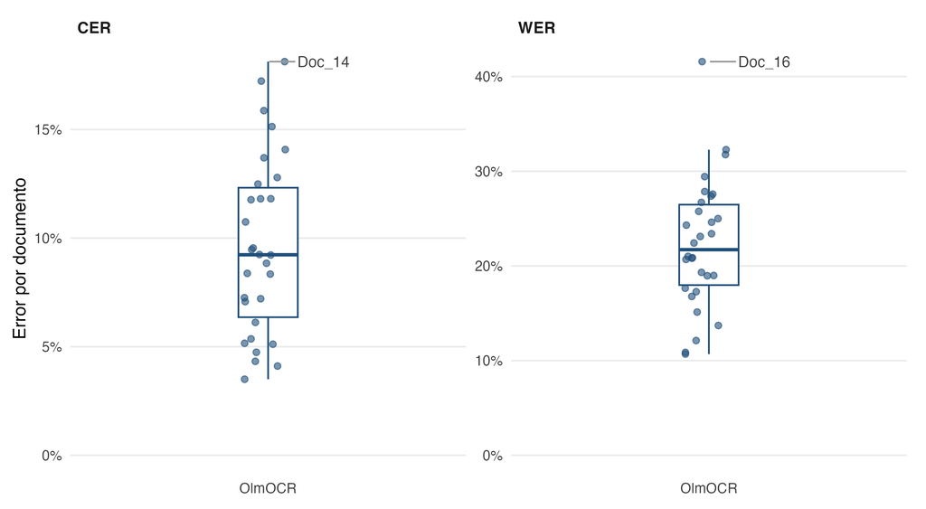

Figura 7. Distribución del CER y del WER entre documentos por motor. Cada punto es un documento (30 por motor); la caja marca la mediana y el rango intercuartílico. No se excluyeron valores extremos y se rotula el documento con mayor error en cada métrica. Cada panel tiene su propia escala vertical.

La dispersión del error entre documentos es tan relevante como su nivel. El IQR del CER de OlmOCR es 6,0 % y su máximo por documento, 18,1 % (2,0 veces la mediana). El documento con mayor CER es Doc_14 (18,1 %).

En cuanto a la forma de la distribución, la asimetría del CER es 0,35 y la del WER, 0,47: un valor cercano a cero indica una distribución aproximadamente simétrica (con solo 30 documentos esta medida es orientativa).

## 3.5 Contraste con OCR: el mismo motor en dos tipos de escritura

El análisis anterior describe a OlmOCR sobre 30 documentos manuscritos. El mismo motor se evaluó también sobre 30 folios impresos y mecanografiados en un análisis OCR aparte, del que se transcriben aquí las cifras de la condición original (archivo Datos/contraste_ocr_olmo.csv, con la fuente de cada cifra); no se recalculan en este reporte. El contraste es descriptivo: cambian el tipo de escritura, el corpus y el número de entidades, de modo que no es un experimento controlado ni permite atribuir causas.

Tabla 4. OlmOCR en folios impresos (cifras del reporte OCR) y en documentos manuscritos (este reporte).

| Indicador | OCR (folios impresos) | ICR (manuscritos) |
| --- | --- | --- |
| CER mediano | 0,5 % | 9,2 % |
| CER, rango intercuartílico | 0,8 % | 6,0 % |
| CER, percentil 90 | 4,9 % | 15,2 % |
| CER máximo por documento | 27,5 % | 18,1 % |
| WER mediano | 1,6 % | 21,7 % |
| Operaciones de edición | 864 | 2.955 |
| Sustituciones (% de las operaciones) | 21,5 % | 54,3 % |
| Omisiones (% de las operaciones) | 66,9 % | 26,2 % |
| Inserciones (% de las operaciones) | 11,6 % | 19,5 % |

Con escritura manuscrita el error típico es mucho mayor (Tabla 4): el CER mediano pasa de 0,5 % a 9,2 % y el WER mediano de 1,6 % a 21,7 %. También cambia la forma en que falla (Figura 8): en los folios impresos predominan las omisiones (66,9 % de las operaciones) y en los manuscritos, las sustituciones (54,3 %).

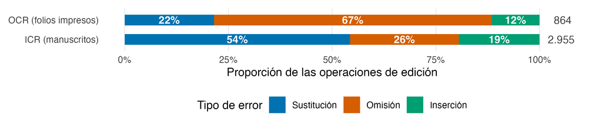

Figura 8. Composición del error de OlmOCR en folios impresos (OCR) y en documentos manuscritos (ICR). Cada barra suma el 100 % de las operaciones de edición; el número a la derecha es el total de operaciones. Los corpus son distintos, por lo que se compara la composición y no el volumen.

La preservación de entidades baja en las cuatro categorías (Figura 9): nombres propios, de 93,7 % a 69,5 %; fechas, de 80,0 % a 56,8 %; códigos administrativos, de 100,0 % a 57,1 %; y números, de 70,9 % a 26,5 %. Dos precauciones limitan la lectura. Primero, en el corpus impreso hay pocas fechas (n = 5) y códigos (n = 11), por lo que una sola entidad mueve la tasa 20 y 9,1 puntos porcentuales. Segundo, la caída en números se debe sobre todo a los ordinales (22 de 34, como 2ª, que la salida escribe con otro signo): sin ellos la preservación de números en el corpus manuscrito sería 66,7 %, cercana al 70,9 % del corpus impreso. Por eso no puede afirmarse que los números sean la categoría que más se degrada con la escritura manuscrita.

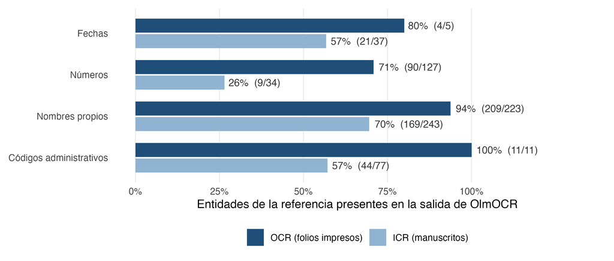

Figura 9. Preservación de entidades por OlmOCR en folios impresos (OCR) y en documentos manuscritos (ICR). Cada barra indica la proporción de entidades de la referencia presentes en la salida, con el conteo entre paréntesis. Los corpus y las cantidades de entidades difieren, y las categorías con pocas entidades son poco precisas.

En estabilidad, el centro del error es más alto y más disperso en los manuscritos (IQR del CER de 6,0 % frente a 0,8 %), pero el máximo por documento es mayor en los folios impresos (27,5 %, Folio_18, frente a 18,1 % en el Doc_14 manuscrito): en el corpus impreso un solo documento difícil produce el fallo extremo, mientras que en el manuscrito el error es alto de forma más generalizada.

# 4 Alcances y límites

- El estudio se basa en 30 documentos de una sola fuente y en una referencia transcrita manualmente, por lo que los resultados describen este conjunto y no deben extrapolarse sin validación a otros tipos de documento.
- Solo se analiza un motor: la estabilidad y la preservación describen a OlmOCR y no hay otro motor contra el cual compararlo.
- Las categorías de entidades tienen tamaños muy desiguales (códigos administrativos: 77, fechas: 37, nombres propios: 243, números: 34), de modo que las tasas de las categorías pequeñas son poco precisas.
- La comparación de entidades es exacta, sin tolerancia a variantes, lo que penaliza incluso diferencias menores de forma (una tilde añadida, un «°» por un «ª»).
- La clasificación de nombres propios usa reglas y un diccionario de exclusión hecho a mano para este corpus; puede quedar ruido en esa categoría. Las mayúsculas arbitrarias del manuscrito (*Si*, *Un*, *Sea*) se descartan si la misma palabra aparece en minúscula en la referencia.
- El contraste con OCR usa cifras transcritas de otro reporte (Reporte OCR v5), calculadas con sus propias reglas de extracción de entidades y de normalización; no se recalcularon aquí y podrían no coincidir con las de este reporte en los detalles. Solo se contrasta OlmOCR, el único motor con salida en ambos corpus.
- Las palabras cortadas por guion de fin de línea (*pre- sente*) se comparan tal como están en la referencia; una salida que las une cuenta como error.

# 5 Conclusiones

Las cifras de CER y WER de OlmOCR (9,2 % y 21,7 % de mediana) no dicen por sí solas qué información se conserva. Su perfil de error de carácter está dominado por las sustituciones (54,3 %), y la conservación de entidades depende de la categoría: 69,5 % en nombres propios, 56,8 % en fechas y 57,1 % en códigos administrativos. La estabilidad entre documentos también importa: el CER máximo por documento (18,1 %) equivale a 2,0 veces la mediana.

Frente al corpus impreso, el mismo motor tiene un error típico mucho mayor en manuscritos y cambia su perfil de error, de omisiones a sustituciones; parte de la caída en números se explica por los ordinales y no por una pérdida general de dígitos.

Con un solo motor, estos resultados describen su comportamiento pero no permiten declarar un motor mejor que otro. El siguiente paso es agregar las salidas de otros motores en `config.yml` y compilar de nuevo.

# Apéndice

## A. CER y WER completos

Tabla 5. CER y WER por motor (n: número de documentos; la asimetría es la de Fisher-Pearson entre documentos).

| Motor | n | CER medio | CER mediano | CER asimetría | WER medio | WER mediano | WER asimetría |
| --- | --- | --- | --- | --- | --- | --- | --- |
| OlmOCR | 30 | 9,6 % | 9,2 % | 0,35 | 22,3 % | 21,7 % | 0,47 |

## B. Errores por operación y tipo

La Tabla 6 desglosa las sustituciones, omisiones e inserciones de la Tabla 1 según el tipo de carácter implicado, y expresa cada tipo como porcentaje de los errores y por cada 100 caracteres de la referencia.

Tabla 6. Errores de carácter por operación y tipo. La última columna son errores por cada 100 caracteres de la referencia.

| Motor | Operación | Tipo | n | % de errores | Por 100 car. |
| --- | --- | --- | --- | --- | --- |
| OlmOCR | sustitución | letra por otra letra | 1.170 | 39,6 % | 3,91 |
| OlmOCR | omisión | letra | 490 | 16,6 % | 1,64 |
| OlmOCR | inserción | letra | 429 | 14,5 % | 1,43 |
| OlmOCR | omisión | puntuación/símbolo | 165 | 5,6 % | 0,55 |
| OlmOCR | sustitución | acento añadido | 154 | 5,2 % | 0,51 |
| OlmOCR | sustitución | puntuación/símbolo | 98 | 3,3 % | 0,33 |
| OlmOCR | omisión | espacio | 97 | 3,3 % | 0,32 |
| OlmOCR | inserción | puntuación/símbolo | 81 | 2,7 % | 0,27 |
| OlmOCR | sustitución | mayúscula/minúscula | 74 | 2,5 % | 0,25 |
| OlmOCR | sustitución | espacio | 53 | 1,8 % | 0,18 |
| OlmOCR | sustitución | acento perdido | 49 | 1,7 % | 0,16 |
| OlmOCR | inserción | espacio | 47 | 1,6 % | 0,16 |
| OlmOCR | omisión | letra acentuada | 19 | 0,6 % | 0,06 |
| OlmOCR | inserción | letra acentuada | 18 | 0,6 % | 0,06 |
| OlmOCR | sustitución | letra/dígito | 7 | 0,2 % | 0,02 |
| OlmOCR | omisión | dígito | 4 | 0,1 % | 0,01 |

## C. Principales sustituciones por motor

Cinco sustituciones más frecuentes dentro de cada motor.

**OlmOCR**

| Referencia | ICR | Frecuencia |
| --- | --- | --- |
| i | í | 77 |
| a | o | 46 |
| e | a | 30 |
| a | á | 28 |
| o | ó | 27 |

## D. Preservación de entidades por categoría

**Fechas**

| Motor | Entidades de referencia | Preservadas | Tasa |
| --- | --- | --- | --- |
| OlmOCR | 37 | 21 | 57 % |

**Números**

| Motor | Entidades de referencia | Preservadas | Tasa |
| --- | --- | --- | --- |
| OlmOCR | 34 | 9 | 26 % |

**Nombres propios**

| Motor | Entidades de referencia | Preservadas | Tasa |
| --- | --- | --- | --- |
| OlmOCR | 243 | 169 | 70 % |

**Códigos administrativos**

| Motor | Entidades de referencia | Preservadas | Tasa |
| --- | --- | --- | --- |
| OlmOCR | 77 | 44 | 57 % |

## E. Integración tabular con tidytext

Con `tidytext::unnest_tokens()` se construyó una tabla de tokens (una palabra por fila) para la referencia y para la salida de cada motor. Una palabra es una secuencia de letras o dígitos, en minúscula y con sus tildes, la misma definición del WER. Esta capa no modifica CER ni WER; permite observar cuánto texto y cuánto vocabulario distinto produce cada motor frente a la referencia.

Tabla 7. Volumen de tokens totales y únicos por motor.

| Motor | Tokens referencia | Tokens ICR | ICR / referencia | Únicos referencia | Únicos ICR | Únicos ICR / referencia |
| --- | --- | --- | --- | --- | --- | --- |
| OlmOCR | 5.229 | 5.155 | 98,6 % | 1.767 | 1.732 | 98,0 % |

En OlmOCR, 489 palabras distintas de la salida no existen en la referencia y 524 palabras de la referencia no aparecen en la salida. De las añadidas, 47 (9,6 %) coinciden con una palabra perdida al quitar las tildes: son la misma palabra escrita con otra tilde.

Tabla 8. Palabras más repetidas que el motor escribe y la referencia no tiene.

| Palabra | Veces |
| --- | --- |
| indígena | 14 |
| había | 6 |
| chávez | 4 |
| aviso | 3 |
| hablado | 3 |
| indígenas | 3 |
| límites | 3 |
| martínez | 3 |
| mucha | 3 |
| pública | 3 |

Tabla 9. Palabras más repetidas de la referencia que el motor nunca escribe.

| Palabra | Veces |
| --- | --- |
| indigena | 12 |
| 5ª | 7 |
| declaracion | 5 |
| do | 5 |
| habia | 5 |
| 3ª | 4 |
| 4ª | 4 |
| chavez | 4 |
| conosco | 4 |
| ningun | 4 |

## F. Reproducibilidad

El reporte se genera con `quarto render reporte.qmd`. Las rutas y los motores se definen en `config.yml` (para otra configuración: `LATINR_CONFIG=mi_config.yml quarto render reporte.qmd`). El reporte lee las salidas ya producidas y no ejecuta ningún motor ICR; las cifras OCR del contraste se leen de `Datos/contraste_ocr_olmo.csv` (clave `contraste_ocr`), que puede omitirse. Las pruebas de las funciones de análisis se ejecutan con `testthat` desde `tests/testthat/`.